# Risk Factor Analysis

## Outcome Variable

**Outcome Variable:** ever_wasted

## Predictor Variables

**Intervention Variable:** nrooms

**Adjustment Set:**

- arm
- sex
- W_mage
- meducyrs
- feducyrs
- hhwealth_quart
- hfoodsec
- W_mhtcm
- W_nchldlt5
- W_parity
- impfloor
- impsan
- safeh20
- delta_W_mage
- delta_meducyrs
- delta_feducyrs
- delta_hhwealth_quart
- delta_hfoodsec
- delta_W_mhtcm
- delta_W_nchldlt5
- delta_W_parity
- delta_impfloor
- delta_impsan
- delta_safeh20

## Stratifying Variables

The analysis was stratified on these variable(s):

- agecat
- studyid
- country

## Data Summary

| agecat | studyid | country | nrooms | ever_wasted | n_cell | n |
| --- | --- | --- | --- | --- | --- | --- |
| 0-24 months | ki0047075b-MAL-ED | BANGLADESH | 4+ | 0 | 9 | 242 |
| 0-24 months | ki0047075b-MAL-ED | BANGLADESH | 4+ | 1 | 3 | 242 |
| 0-24 months | ki0047075b-MAL-ED | BANGLADESH | 1 | 0 | 92 | 242 |
| 0-24 months | ki0047075b-MAL-ED | BANGLADESH | 1 | 1 | 60 | 242 |
| 0-24 months | ki0047075b-MAL-ED | BANGLADESH | 2 | 0 | 37 | 242 |
| 0-24 months | ki0047075b-MAL-ED | BANGLADESH | 2 | 1 | 13 | 242 |
| 0-24 months | ki0047075b-MAL-ED | BANGLADESH | 3 | 0 | 20 | 242 |
| 0-24 months | ki0047075b-MAL-ED | BANGLADESH | 3 | 1 | 8 | 242 |
| 0-24 months | ki0047075b-MAL-ED | BRAZIL | 4+ | 0 | 114 | 210 |
| 0-24 months | ki0047075b-MAL-ED | BRAZIL | 4+ | 1 | 13 | 210 |
| 0-24 months | ki0047075b-MAL-ED | BRAZIL | 1 | 0 | 4 | 210 |
| 0-24 months | ki0047075b-MAL-ED | BRAZIL | 1 | 1 | 0 | 210 |
| 0-24 months | ki0047075b-MAL-ED | BRAZIL | 2 | 0 | 18 | 210 |
| 0-24 months | ki0047075b-MAL-ED | BRAZIL | 2 | 1 | 2 | 210 |
| 0-24 months | ki0047075b-MAL-ED | BRAZIL | 3 | 0 | 55 | 210 |
| 0-24 months | ki0047075b-MAL-ED | BRAZIL | 3 | 1 | 4 | 210 |
| 0-24 months | ki0047075b-MAL-ED | INDIA | 4+ | 0 | 16 | 235 |
| 0-24 months | ki0047075b-MAL-ED | INDIA | 4+ | 1 | 9 | 235 |
| 0-24 months | ki0047075b-MAL-ED | INDIA | 1 | 0 | 43 | 235 |
| 0-24 months | ki0047075b-MAL-ED | INDIA | 1 | 1 | 41 | 235 |
| 0-24 months | ki0047075b-MAL-ED | INDIA | 2 | 0 | 38 | 235 |
| 0-24 months | ki0047075b-MAL-ED | INDIA | 2 | 1 | 40 | 235 |
| 0-24 months | ki0047075b-MAL-ED | INDIA | 3 | 0 | 25 | 235 |
| 0-24 months | ki0047075b-MAL-ED | INDIA | 3 | 1 | 23 | 235 |
| 0-24 months | ki0047075b-MAL-ED | NEPAL | 4+ | 0 | 95 | 236 |
| 0-24 months | ki0047075b-MAL-ED | NEPAL | 4+ | 1 | 36 | 236 |
| 0-24 months | ki0047075b-MAL-ED | NEPAL | 1 | 0 | 31 | 236 |
| 0-24 months | ki0047075b-MAL-ED | NEPAL | 1 | 1 | 21 | 236 |
| 0-24 months | ki0047075b-MAL-ED | NEPAL | 2 | 0 | 26 | 236 |
| 0-24 months | ki0047075b-MAL-ED | NEPAL | 2 | 1 | 5 | 236 |

[output cut: 354 more lines]

The following strata were considered:

- agecat: 0-24 months, studyid: ki0047075b-MAL-ED, country: BANGLADESH
- agecat: 0-24 months, studyid: ki0047075b-MAL-ED, country: BRAZIL
- agecat: 0-24 months, studyid: ki0047075b-MAL-ED, country: INDIA
- agecat: 0-24 months, studyid: ki0047075b-MAL-ED, country: NEPAL
- agecat: 0-24 months, studyid: ki0047075b-MAL-ED, country: PERU
- agecat: 0-24 months, studyid: ki0047075b-MAL-ED, country: SOUTH AFRICA
- agecat: 0-24 months, studyid: ki0047075b-MAL-ED, country: TANZANIA, UNITED REPUBLIC OF
- agecat: 0-24 months, studyid: ki1000108-CMC-V-BCS-2002, country: INDIA
- agecat: 0-24 months, studyid: ki1000108-IRC, country: INDIA
- agecat: 0-24 months, studyid: ki1017093b-PROVIDE, country: BANGLADESH
- agecat: 0-24 months, studyid: ki1017093c-NIH-Crypto, country: BANGLADESH
- agecat: 0-24 months, studyid: ki1113344-GMS-Nepal, country: NEPAL
- agecat: 0-24 months, studyid: ki1114097-CONTENT, country: PERU
- agecat: 0-24 months, studyid: ki1135781-COHORTS, country: INDIA
- agecat: 0-24 months, studyid: kiGH5241-JiVitA-3, country: BANGLADESH
- agecat: 0-24 months, studyid: kiGH5241-JiVitA-4, country: BANGLADESH
- agecat: 0-6 months, studyid: ki0047075b-MAL-ED, country: BANGLADESH
- agecat: 0-6 months, studyid: ki0047075b-MAL-ED, country: BRAZIL
- agecat: 0-6 months, studyid: ki0047075b-MAL-ED, country: INDIA
- agecat: 0-6 months, studyid: ki0047075b-MAL-ED, country: NEPAL
- agecat: 0-6 months, studyid: ki0047075b-MAL-ED, country: PERU
- agecat: 0-6 months, studyid: ki0047075b-MAL-ED, country: SOUTH AFRICA
- agecat: 0-6 months, studyid: ki0047075b-MAL-ED, country: TANZANIA, UNITED REPUBLIC OF
- agecat: 0-6 months, studyid: ki1000108-CMC-V-BCS-2002, country: INDIA
- agecat: 0-6 months, studyid: ki1000108-IRC, country: INDIA
- agecat: 0-6 months, studyid: ki1017093b-PROVIDE, country: BANGLADESH
- agecat: 0-6 months, studyid: ki1017093c-NIH-Crypto, country: BANGLADESH
- agecat: 0-6 months, studyid: ki1113344-GMS-Nepal, country: NEPAL
- agecat: 0-6 months, studyid: ki1114097-CONTENT, country: PERU
- agecat: 0-6 months, studyid: ki1135781-COHORTS, country: INDIA
- agecat: 0-6 months, studyid: kiGH5241-JiVitA-3, country: BANGLADESH
- agecat: 0-6 months, studyid: kiGH5241-JiVitA-4, country: BANGLADESH
- agecat: 6-24 months, studyid: ki0047075b-MAL-ED, country: BANGLADESH
- agecat: 6-24 months, studyid: ki0047075b-MAL-ED, country: BRAZIL
- agecat: 6-24 months, studyid: ki0047075b-MAL-ED, country: INDIA
- agecat: 6-24 months, studyid: ki0047075b-MAL-ED, country: NEPAL
- agecat: 6-24 months, studyid: ki0047075b-MAL-ED, country: PERU
- agecat: 6-24 months, studyid: ki0047075b-MAL-ED, country: SOUTH AFRICA
- agecat: 6-24 months, studyid: ki0047075b-MAL-ED, country: TANZANIA, UNITED REPUBLIC OF
- agecat: 6-24 months, studyid: ki1000108-CMC-V-BCS-2002, country: INDIA
- agecat: 6-24 months, studyid: ki1000108-IRC, country: INDIA
- agecat: 6-24 months, studyid: ki1017093b-PROVIDE, country: BANGLADESH
- agecat: 6-24 months, studyid: ki1017093c-NIH-Crypto, country: BANGLADESH
- agecat: 6-24 months, studyid: ki1113344-GMS-Nepal, country: NEPAL
- agecat: 6-24 months, studyid: ki1114097-CONTENT, country: PERU
- agecat: 6-24 months, studyid: ki1135781-COHORTS, country: INDIA
- agecat: 6-24 months, studyid: kiGH5241-JiVitA-3, country: BANGLADESH
- agecat: 6-24 months, studyid: kiGH5241-JiVitA-4, country: BANGLADESH

### Dropped Strata

Some strata were dropped due to rare outcomes:

- agecat: 0-24 months, studyid: ki0047075b-MAL-ED, country: BANGLADESH
- agecat: 0-24 months, studyid: ki0047075b-MAL-ED, country: BRAZIL
- agecat: 0-24 months, studyid: ki0047075b-MAL-ED, country: PERU
- agecat: 0-24 months, studyid: ki0047075b-MAL-ED, country: SOUTH AFRICA
- agecat: 0-24 months, studyid: ki0047075b-MAL-ED, country: TANZANIA, UNITED REPUBLIC OF
- agecat: 0-24 months, studyid: ki1114097-CONTENT, country: PERU
- agecat: 0-6 months, studyid: ki0047075b-MAL-ED, country: BANGLADESH
- agecat: 0-6 months, studyid: ki0047075b-MAL-ED, country: BRAZIL
- agecat: 0-6 months, studyid: ki0047075b-MAL-ED, country: NEPAL
- agecat: 0-6 months, studyid: ki0047075b-MAL-ED, country: PERU
- agecat: 0-6 months, studyid: ki0047075b-MAL-ED, country: SOUTH AFRICA
- agecat: 0-6 months, studyid: ki0047075b-MAL-ED, country: TANZANIA, UNITED REPUBLIC OF
- agecat: 0-6 months, studyid: ki1000108-CMC-V-BCS-2002, country: INDIA
- agecat: 0-6 months, studyid: ki1114097-CONTENT, country: PERU
- agecat: 6-24 months, studyid: ki0047075b-MAL-ED, country: BANGLADESH
- agecat: 6-24 months, studyid: ki0047075b-MAL-ED, country: BRAZIL
- agecat: 6-24 months, studyid: ki0047075b-MAL-ED, country: INDIA
- agecat: 6-24 months, studyid: ki0047075b-MAL-ED, country: NEPAL
- agecat: 6-24 months, studyid: ki0047075b-MAL-ED, country: PERU
- agecat: 6-24 months, studyid: ki0047075b-MAL-ED, country: SOUTH AFRICA
- agecat: 6-24 months, studyid: ki0047075b-MAL-ED, country: TANZANIA, UNITED REPUBLIC OF
- agecat: 6-24 months, studyid: ki1000108-CMC-V-BCS-2002, country: INDIA
- agecat: 6-24 months, studyid: ki1017093b-PROVIDE, country: BANGLADESH
- agecat: 6-24 months, studyid: ki1114097-CONTENT, country: PERU
- agecat: 6-24 months, studyid: ki1135781-COHORTS, country: INDIA

## Methods Detail

We’re interested in the causal parameters $E[Y_a]$ for all values of $a \in \mathcal{A}$. These parameters represent the mean outcome if, possibly contrary to fact, we intervened to set all units to have $A=a$. Under the randomization and positivity assumptions, these are identified by the statistical parameters $\psi_a=E_W[E_{Y|A,W}(Y|A=a,W)]$. In addition, we’re interested in the mean of $Y$, $E[Y]$ under no intervention (the observed mean). We will estimate these parameters by using SuperLearner to fit the relevant likelihood factors – $E_{Y|A,W}(Y|A=a,W)$ and $p(A=a|W)$, and then updating our likelihood fit using a joint TMLE.

For unadjusted analyses ($W=\{\}$), initial likelihoods were estimated using Lrnr_glm to estimate the simple $E(Y|A)$ and Lrnr_mean to estimate $p(A)$. For adjusted analyses, a small library containing Lrnr_glmnet, Lrnr_xgboost, and Lrnr_mean was used.

Having estimated these parameters, we will then use the delta method to estimate relative risks and attributable risks relative to a prespecified baseline level of $A$.

# Results Detail

## Results Plots

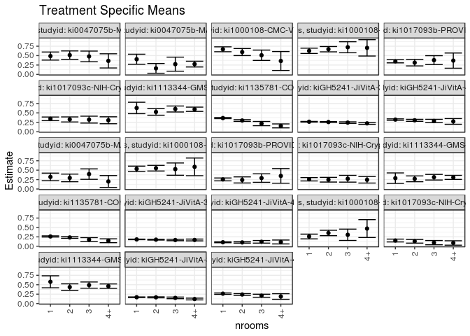

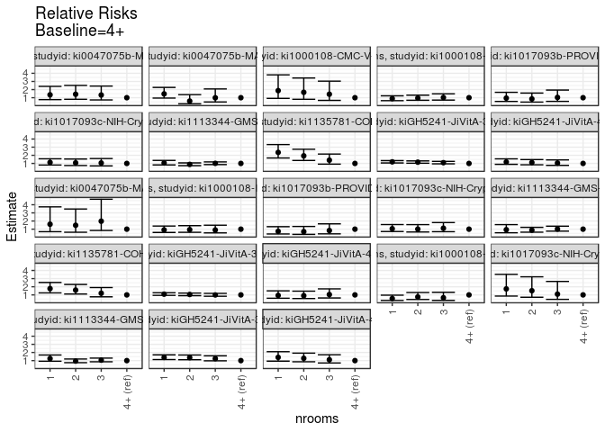

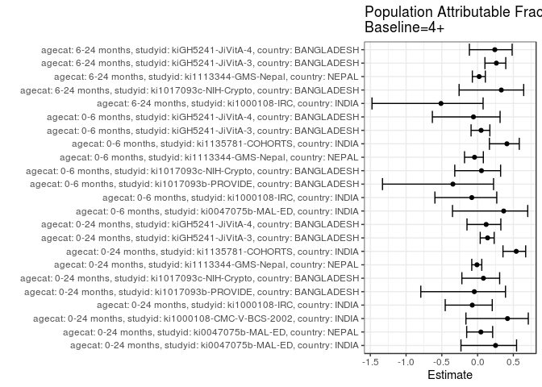

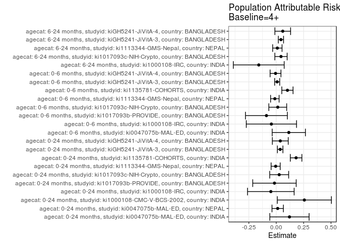

## Results Table

### Parameter: TSM

| agecat | studyid | country | intervention_level | baseline_level | estimate | ci_lower | ci_upper |
| --- | --- | --- | --- | --- | --- | --- | --- |
| 0-24 months | ki0047075b-MAL-ED | INDIA | 4+ | NA | 0.3600000 | 0.1714418 | 0.5485582 |
| 0-24 months | ki0047075b-MAL-ED | INDIA | 1 | NA | 0.4880952 | 0.3809726 | 0.5952179 |
| 0-24 months | ki0047075b-MAL-ED | INDIA | 2 | NA | 0.5128205 | 0.4016591 | 0.6239819 |
| 0-24 months | ki0047075b-MAL-ED | INDIA | 3 | NA | 0.4791667 | 0.3375396 | 0.6207937 |
| 0-24 months | ki0047075b-MAL-ED | NEPAL | 4+ | NA | 0.2748092 | 0.1982008 | 0.3514175 |
| 0-24 months | ki0047075b-MAL-ED | NEPAL | 1 | NA | 0.4038462 | 0.2702003 | 0.5374921 |
| 0-24 months | ki0047075b-MAL-ED | NEPAL | 2 | NA | 0.1612903 | 0.0315427 | 0.2910379 |
| 0-24 months | ki0047075b-MAL-ED | NEPAL | 3 | NA | 0.2727273 | 0.0862303 | 0.4592242 |
| 0-24 months | ki1000108-CMC-V-BCS-2002 | INDIA | 4+ | NA | 0.3571429 | 0.1058123 | 0.6084734 |
| 0-24 months | ki1000108-CMC-V-BCS-2002 | INDIA | 1 | NA | 0.6683168 | 0.6033026 | 0.7333310 |
| 0-24 months | ki1000108-CMC-V-BCS-2002 | INDIA | 2 | NA | 0.5943396 | 0.5007394 | 0.6879398 |
| 0-24 months | ki1000108-CMC-V-BCS-2002 | INDIA | 3 | NA | 0.5098039 | 0.3724211 | 0.6471867 |
| 0-24 months | ki1000108-IRC | INDIA | 4+ | NA | 0.7058824 | 0.4890205 | 0.9227442 |
| 0-24 months | ki1000108-IRC | INDIA | 1 | NA | 0.6270270 | 0.5572557 | 0.6967983 |
| 0-24 months | ki1000108-IRC | INDIA | 2 | NA | 0.6705882 | 0.5998500 | 0.7413264 |
| 0-24 months | ki1000108-IRC | INDIA | 3 | NA | 0.7222222 | 0.5757302 | 0.8687142 |
| 0-24 months | ki1017093b-PROVIDE | BANGLADESH | 4+ | NA | 0.3675018 | 0.1658582 | 0.5691454 |
| 0-24 months | ki1017093b-PROVIDE | BANGLADESH | 1 | NA | 0.3491927 | 0.3075854 | 0.3908000 |
| 0-24 months | ki1017093b-PROVIDE | BANGLADESH | 2 | NA | 0.3126089 | 0.2262785 | 0.3989393 |
| 0-24 months | ki1017093b-PROVIDE | BANGLADESH | 3 | NA | 0.3801761 | 0.2622665 | 0.4980856 |
| 0-24 months | ki1017093c-NIH-Crypto | BANGLADESH | 4+ | NA | 0.3041129 | 0.2122000 | 0.3960259 |
| 0-24 months | ki1017093c-NIH-Crypto | BANGLADESH | 1 | NA | 0.3419757 | 0.2935175 | 0.3904339 |
| 0-24 months | ki1017093c-NIH-Crypto | BANGLADESH | 2 | NA | 0.3260696 | 0.2588420 | 0.3932973 |
| 0-24 months | ki1017093c-NIH-Crypto | BANGLADESH | 3 | NA | 0.3214728 | 0.2299373 | 0.4130083 |
| 0-24 months | ki1113344-GMS-Nepal | NEPAL | 4+ | NA | 0.5966236 | 0.5397320 | 0.6535151 |
| 0-24 months | ki1113344-GMS-Nepal | NEPAL | 1 | NA | 0.6310133 | 0.4791537 | 0.7828730 |
| 0-24 months | ki1113344-GMS-Nepal | NEPAL | 2 | NA | 0.5254093 | 0.4380522 | 0.6127664 |
| 0-24 months | ki1113344-GMS-Nepal | NEPAL | 3 | NA | 0.6034741 | 0.5243755 | 0.6825726 |
| 0-24 months | ki1135781-COHORTS | INDIA | 4+ | NA | 0.1541487 | 0.1016334 | 0.2066640 |
| 0-24 months | ki1135781-COHORTS | INDIA | 1 | NA | 0.3629505 | 0.3469761 | 0.3789248 |

[output cut: 62 more lines]

### Parameter: E(Y)

| agecat | studyid | country | intervention_level | baseline_level | estimate | ci_lower | ci_upper |
| --- | --- | --- | --- | --- | --- | --- | --- |
| 0-24 months | ki0047075b-MAL-ED | INDIA | NA | NA | 0.4808511 | 0.4168346 | 0.5448675 |
| 0-24 months | ki0047075b-MAL-ED | NEPAL | NA | NA | 0.2881356 | 0.2302312 | 0.3460400 |
| 0-24 months | ki1000108-CMC-V-BCS-2002 | INDIA | NA | NA | 0.6139410 | 0.5644682 | 0.6634139 |
| 0-24 months | ki1000108-IRC | INDIA | NA | NA | 0.6568627 | 0.6107393 | 0.7029862 |
| 0-24 months | ki1017093b-PROVIDE | BANGLADESH | NA | NA | 0.3514286 | 0.3160364 | 0.3868207 |
| 0-24 months | ki1017093c-NIH-Crypto | BANGLADESH | NA | NA | 0.3311346 | 0.2976093 | 0.3646598 |
| 0-24 months | ki1113344-GMS-Nepal | NEPAL | NA | NA | 0.5913621 | 0.5520608 | 0.6306634 |
| 0-24 months | ki1135781-COHORTS | INDIA | NA | NA | 0.3354454 | 0.3228114 | 0.3480794 |
| 0-24 months | kiGH5241-JiVitA-3 | BANGLADESH | NA | NA | 0.2580394 | 0.2515717 | 0.2645070 |
| 0-24 months | kiGH5241-JiVitA-4 | BANGLADESH | NA | NA | 0.3101161 | 0.2957091 | 0.3245231 |
| 0-6 months | ki0047075b-MAL-ED | INDIA | NA | NA | 0.3148936 | 0.2553821 | 0.3744051 |
| 0-6 months | ki1000108-IRC | INDIA | NA | NA | 0.5441176 | 0.4957312 | 0.5925041 |
| 0-6 months | ki1017093b-PROVIDE | BANGLADESH | NA | NA | 0.2585714 | 0.2261125 | 0.2910304 |
| 0-6 months | ki1017093c-NIH-Crypto | BANGLADESH | NA | NA | 0.2585752 | 0.2273844 | 0.2897660 |
| 0-6 months | ki1113344-GMS-Nepal | NEPAL | NA | NA | 0.2956811 | 0.2591967 | 0.3321655 |
| 0-6 months | ki1135781-COHORTS | INDIA | NA | NA | 0.2494186 | 0.2376119 | 0.2612253 |
| 0-6 months | kiGH5241-JiVitA-3 | BANGLADESH | NA | NA | 0.1763127 | 0.1706830 | 0.1819425 |
| 0-6 months | kiGH5241-JiVitA-4 | BANGLADESH | NA | NA | 0.1078103 | 0.0979895 | 0.1176312 |
| 6-24 months | ki1000108-IRC | INDIA | NA | NA | 0.3112745 | 0.2662918 | 0.3562572 |
| 6-24 months | ki1017093c-NIH-Crypto | BANGLADESH | NA | NA | 0.1315069 | 0.1069744 | 0.1560393 |
| 6-24 months | ki1113344-GMS-Nepal | NEPAL | NA | NA | 0.4728814 | 0.4325613 | 0.5132014 |
| 6-24 months | kiGH5241-JiVitA-3 | BANGLADESH | NA | NA | 0.1637742 | 0.1576516 | 0.1698967 |
| 6-24 months | kiGH5241-JiVitA-4 | BANGLADESH | NA | NA | 0.2472801 | 0.2337480 | 0.2608122 |

### Parameter: RR

| agecat | studyid | country | intervention_level | baseline_level | estimate | ci_lower | ci_upper |
| --- | --- | --- | --- | --- | --- | --- | --- |
| 0-24 months | ki0047075b-MAL-ED | INDIA | 4+ | 4+ | 1.0000000 | 1.0000000 | 1.0000000 |
| 0-24 months | ki0047075b-MAL-ED | INDIA | 1 | 4+ | 1.3558201 | 0.7683661 | 2.3924117 |
| 0-24 months | ki0047075b-MAL-ED | INDIA | 2 | 4+ | 1.4245014 | 0.8081293 | 2.5109898 |
| 0-24 months | ki0047075b-MAL-ED | INDIA | 3 | 4+ | 1.3310185 | 0.7294461 | 2.4287062 |
| 0-24 months | ki0047075b-MAL-ED | NEPAL | 4+ | 4+ | 1.0000000 | 1.0000000 | 1.0000000 |
| 0-24 months | ki0047075b-MAL-ED | NEPAL | 1 | 4+ | 1.4695513 | 0.9533794 | 2.2651853 |
| 0-24 months | ki0047075b-MAL-ED | NEPAL | 2 | 4+ | 0.5869176 | 0.2505143 | 1.3750601 |
| 0-24 months | ki0047075b-MAL-ED | NEPAL | 3 | 4+ | 0.9924242 | 0.4742285 | 2.0768592 |
| 0-24 months | ki1000108-CMC-V-BCS-2002 | INDIA | 4+ | 4+ | 1.0000000 | 1.0000000 | 1.0000000 |
| 0-24 months | ki1000108-CMC-V-BCS-2002 | INDIA | 1 | 4+ | 1.8712871 | 0.9196234 | 3.8077711 |
| 0-24 months | ki1000108-CMC-V-BCS-2002 | INDIA | 2 | 4+ | 1.6641509 | 0.8091128 | 3.4227594 |
| 0-24 months | ki1000108-CMC-V-BCS-2002 | INDIA | 3 | 4+ | 1.4274510 | 0.6718852 | 3.0326854 |
| 0-24 months | ki1000108-IRC | INDIA | 4+ | 4+ | 1.0000000 | 1.0000000 | 1.0000000 |
| 0-24 months | ki1000108-IRC | INDIA | 1 | 4+ | 0.8882883 | 0.6406895 | 1.2315733 |
| 0-24 months | ki1000108-IRC | INDIA | 2 | 4+ | 0.9500000 | 0.6865201 | 1.3146009 |
| 0-24 months | ki1000108-IRC | INDIA | 3 | 4+ | 1.0231481 | 0.7080395 | 1.4784939 |
| 0-24 months | ki1017093b-PROVIDE | BANGLADESH | 4+ | 4+ | 1.0000000 | 1.0000000 | 1.0000000 |
| 0-24 months | ki1017093b-PROVIDE | BANGLADESH | 1 | 4+ | 0.9501797 | 0.5419481 | 1.6659187 |
| 0-24 months | ki1017093b-PROVIDE | BANGLADESH | 2 | 4+ | 0.8506323 | 0.4602940 | 1.5719851 |
| 0-24 months | ki1017093b-PROVIDE | BANGLADESH | 3 | 4+ | 1.0344877 | 0.5513629 | 1.9409447 |
| 0-24 months | ki1017093c-NIH-Crypto | BANGLADESH | 4+ | 4+ | 1.0000000 | 1.0000000 | 1.0000000 |
| 0-24 months | ki1017093c-NIH-Crypto | BANGLADESH | 1 | 4+ | 1.1245023 | 0.8052390 | 1.5703478 |
| 0-24 months | ki1017093c-NIH-Crypto | BANGLADESH | 2 | 4+ | 1.0721991 | 0.7437595 | 1.5456756 |
| 0-24 months | ki1017093c-NIH-Crypto | BANGLADESH | 3 | 4+ | 1.0570835 | 0.6979633 | 1.6009803 |
| 0-24 months | ki1113344-GMS-Nepal | NEPAL | 4+ | 4+ | 1.0000000 | 1.0000000 | 1.0000000 |
| 0-24 months | ki1113344-GMS-Nepal | NEPAL | 1 | 4+ | 1.0576406 | 0.8162844 | 1.3703603 |
| 0-24 months | ki1113344-GMS-Nepal | NEPAL | 2 | 4+ | 0.8806378 | 0.7270389 | 1.0666870 |
| 0-24 months | ki1113344-GMS-Nepal | NEPAL | 3 | 4+ | 1.0114821 | 0.8601991 | 1.1893712 |
| 0-24 months | ki1135781-COHORTS | INDIA | 4+ | 4+ | 1.0000000 | 1.0000000 | 1.0000000 |
| 0-24 months | ki1135781-COHORTS | INDIA | 1 | 4+ | 2.3545479 | 1.6699617 | 3.3197742 |

[output cut: 62 more lines]

### Parameter: PAR

| agecat | studyid | country | intervention_level | baseline_level | estimate | ci_lower | ci_upper |
| --- | --- | --- | --- | --- | --- | --- | --- |
| 0-24 months | ki0047075b-MAL-ED | INDIA | 4+ | NA | 0.1208511 | -0.0582790 | 0.2999811 |
| 0-24 months | ki0047075b-MAL-ED | NEPAL | 4+ | NA | 0.0133264 | -0.0386961 | 0.0653490 |
| 0-24 months | ki1000108-CMC-V-BCS-2002 | INDIA | 4+ | NA | 0.2567982 | 0.0100740 | 0.5035224 |
| 0-24 months | ki1000108-IRC | INDIA | 4+ | NA | -0.0490196 | -0.2617104 | 0.1636712 |
| 0-24 months | ki1017093b-PROVIDE | BANGLADESH | 4+ | NA | -0.0160732 | -0.2144763 | 0.1823298 |
| 0-24 months | ki1017093c-NIH-Crypto | BANGLADESH | 4+ | NA | 0.0270216 | -0.0592960 | 0.1133392 |
| 0-24 months | ki1113344-GMS-Nepal | NEPAL | 4+ | NA | -0.0052615 | -0.0466826 | 0.0361597 |
| 0-24 months | ki1135781-COHORTS | INDIA | 4+ | NA | 0.1812967 | 0.1285948 | 0.2339986 |
| 0-24 months | kiGH5241-JiVitA-3 | BANGLADESH | 4+ | NA | 0.0360825 | 0.0109665 | 0.0611986 |
| 0-24 months | kiGH5241-JiVitA-4 | BANGLADESH | 4+ | NA | 0.0371694 | -0.0352078 | 0.1095465 |
| 0-6 months | ki0047075b-MAL-ED | INDIA | 4+ | NA | 0.1148936 | -0.0366938 | 0.2664810 |
| 0-6 months | ki1000108-IRC | INDIA | 4+ | NA | -0.0441176 | -0.2735435 | 0.1853082 |
| 0-6 months | ki1017093b-PROVIDE | BANGLADESH | 4+ | NA | -0.0892547 | -0.2803091 | 0.1017998 |
| 0-6 months | ki1017093c-NIH-Crypto | BANGLADESH | 4+ | NA | 0.0140062 | -0.0673683 | 0.0953806 |
| 0-6 months | ki1113344-GMS-Nepal | NEPAL | 4+ | NA | -0.0126614 | -0.0514641 | 0.0261413 |
| 0-6 months | ki1135781-COHORTS | INDIA | 4+ | NA | 0.1022676 | 0.0509079 | 0.1536273 |
| 0-6 months | kiGH5241-JiVitA-3 | BANGLADESH | 4+ | NA | 0.0086896 | -0.0143971 | 0.0317762 |
| 0-6 months | kiGH5241-JiVitA-4 | BANGLADESH | 4+ | NA | -0.0062364 | -0.0557665 | 0.0432937 |
| 6-24 months | ki1000108-IRC | INDIA | 4+ | NA | -0.1593137 | -0.3911659 | 0.0725384 |
| 6-24 months | ki1017093c-NIH-Crypto | BANGLADESH | 4+ | NA | 0.0435947 | -0.0124970 | 0.0996865 |
| 6-24 months | ki1113344-GMS-Nepal | NEPAL | 4+ | NA | 0.0102933 | -0.0325589 | 0.0531456 |
| 6-24 months | kiGH5241-JiVitA-3 | BANGLADESH | 4+ | NA | 0.0429955 | 0.0191116 | 0.0668795 |
| 6-24 months | kiGH5241-JiVitA-4 | BANGLADESH | 4+ | NA | 0.0595896 | -0.0120884 | 0.1312677 |

### Parameter: PAF

| agecat | studyid | country | intervention_level | baseline_level | estimate | ci_lower | ci_upper |
| --- | --- | --- | --- | --- | --- | --- | --- |
| 0-24 months | ki0047075b-MAL-ED | INDIA | 4+ | NA | 0.2513274 | -0.2323288 | 0.5451615 |
| 0-24 months | ki0047075b-MAL-ED | NEPAL | 4+ | NA | 0.0462506 | -0.1524532 | 0.2106942 |
| 0-24 months | ki1000108-CMC-V-BCS-2002 | INDIA | 4+ | NA | 0.4182782 | -0.1631450 | 0.7090645 |
| 0-24 months | ki1000108-IRC | INDIA | 4+ | NA | -0.0746269 | -0.4526773 | 0.2050382 |
| 0-24 months | ki1017093b-PROVIDE | BANGLADESH | 4+ | NA | -0.0457368 | -0.7942652 | 0.3905219 |
| 0-24 months | ki1017093c-NIH-Crypto | BANGLADESH | 4+ | NA | 0.0816031 | -0.2197598 | 0.3085091 |
| 0-24 months | ki1113344-GMS-Nepal | NEPAL | 4+ | NA | -0.0088972 | -0.0814368 | 0.0587767 |
| 0-24 months | ki1135781-COHORTS | INDIA | 4+ | NA | 0.5404656 | 0.3551636 | 0.6725188 |
| 0-24 months | kiGH5241-JiVitA-3 | BANGLADESH | 4+ | NA | 0.1398335 | 0.0368916 | 0.2317724 |
| 0-24 months | kiGH5241-JiVitA-4 | BANGLADESH | 4+ | NA | 0.1198563 | -0.1481855 | 0.3253242 |
| 0-6 months | ki0047075b-MAL-ED | INDIA | 4+ | NA | 0.3648649 | -0.3509078 | 0.7013885 |
| 0-6 months | ki1000108-IRC | INDIA | 4+ | NA | -0.0810811 | -0.5969182 | 0.2681301 |
| 0-6 months | ki1017093b-PROVIDE | BANGLADESH | 4+ | NA | -0.3451838 | -1.3297335 | 0.2232934 |
| 0-6 months | ki1017093c-NIH-Crypto | BANGLADESH | 4+ | NA | 0.0541667 | -0.3191823 | 0.3218521 |
| 0-6 months | ki1113344-GMS-Nepal | NEPAL | 4+ | NA | -0.0428211 | -0.1826579 | 0.0804815 |
| 0-6 months | ki1135781-COHORTS | INDIA | 4+ | NA | 0.4100239 | 0.1655881 | 0.5828537 |
| 0-6 months | kiGH5241-JiVitA-3 | BANGLADESH | 4+ | NA | 0.0492849 | -0.0910759 | 0.1715890 |
| 0-6 months | kiGH5241-JiVitA-4 | BANGLADESH | 4+ | NA | -0.0578462 | -0.6323135 | 0.3144463 |
| 6-24 months | ki1000108-IRC | INDIA | 4+ | NA | -0.5118110 | -1.4765926 | 0.0771302 |
| 6-24 months | ki1017093c-NIH-Crypto | BANGLADESH | 4+ | NA | 0.3315017 | -0.2585388 | 0.6449137 |
| 6-24 months | ki1113344-GMS-Nepal | NEPAL | 4+ | NA | 0.0217672 | -0.0732015 | 0.1083321 |
| 6-24 months | kiGH5241-JiVitA-3 | BANGLADESH | 4+ | NA | 0.2625294 | 0.1025655 | 0.3939805 |
| 6-24 months | kiGH5241-JiVitA-4 | BANGLADESH | 4+ | NA | 0.2409802 | -0.1147231 | 0.4831801 |